# I am not a virgin anymore!

Publications

RNA Biology

Gene expression

Xrn1

MNase-seq

Nucleosomes

Bioinformatics

Don’t worry, I am not talking about my romantic life but I have been recently told that the article I had been working in during my master’s thesis -around 2018-, has been officially published in RNA Biology under the title ‘Xrn1 influence on gene transcription results from the combination of general effects on elongating RNA pol II and gene-specific chromatin configuration’, being the first journal paper in which I appear in the authors list. Nevertheless, I am not going to explain this article, since I only worked in the MNase-seq data analysis, but… what is MNase-seq?

Adrià Mitjavila Ventura https://amitjavilaventura.github.io  
12-07-2020

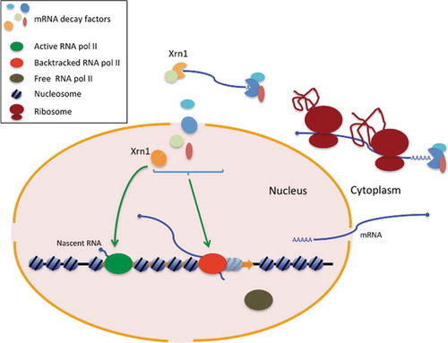

Figure 1: Figure 1 of the article showing the model of how Xrn1 and other RNA decay factors work. Source: Begley V et al (2020). Xrn1 influence on gene transcription results from the combination of general effects on elongating RNA pol II and gene-specific chromatin configuration. RNA Biology. doi: 10.1080/15476286.2020.1845504.

If you want to know more about it, read [my post in BioBit](https://biobit.netlify.app/posts/2020_12_01-xrn1_mnaseseq/).

The article can be found at:

- Begley V *et al* (2020). **Xrn1 influence on gene transcription results from the combination of general effects on elongating RNA pol II and gene-specific chromatin configuration**. **RNA Biology**. [doi: 10.1080/15476286.2020.1845504.](https://www.tandfonline.com/doi/abs/10.1080/15476286.2020.1845504?journalCode=krnb20)